# AlleleFlux p-value heatmap — pre vs end, HF vs LF (breadth ≥ 0.5, coverage ≥ 1)

Author

Siddharth Uppal

Published

2026-09-14

This notebook draws the per-MAG p-value heatmap (Extended Data figure) from the AlleleFlux run configured in `alleleflux_config.yaml` (submitted with `run_alleleflux.sh`). QC thresholds for that run: breadth ≥ 0.5, mean coverage ≥ 1, MAPQ ≥ 20. Only the `pre_end` period and the `fat_control` (HF vs LF) group pair are shown; the input is the pipeline’s own `significant_sites_summary` rollup, so no permutation (null) run is needed for this figure.

```r
# data.table reads / reshapes the long summary table; ComplexHeatmap + circlize + grid draw
# the two-panel heatmap (ComplexHeatmap draws straight to a graphics device, so there is no
# ggplot/ggsave here).
suppressPackageStartupMessages({
  library(data.table)
  library(ComplexHeatmap)
  library(circlize)
  library(grid)
})
```

## Parameters (the only knobs)

```r
# ===================== DATASET KNOBS — edit these to retarget ========================
# `run_dir` is the run's data-type directory (holds p_value_summary/, scores/, ...). It is
# <output.root_dir>/<analysis.data_type> from alleleflux_config.yaml.
run_dir <- "/scratch/gpfs/AMOELLER/sidd/diet_manip/revision_July_2026/AlleleFlux_revision/AlleleFlux/longitudinal"

# GTDB taxonomy table (user_genome + classification); same file as input.gtdb_path in the
# config. Used only for the phylum colour bar / row grouping.
gtdb_path <- "/scratch/gpfs/AMOELLER/diet_manip/gtdbtk.bac120.summary.tsv"

# Where the figure PNG is written (created if absent). Relative to this notebook's
# directory when rendered with `quarto render pvalue_heatmap_pre_end.qmd`.
fig_dir <- "figures"

# Period and group pair to draw. Names follow the config's timepoints_combinations
# (["pre","end"] -> "pre_end") and groups_combinations (treatment_control -> "fat_control";
# HF = fat, LF = control).
sel_period <- "pre_end"
sel_group_pair <- "fat_control"

# ===================== HEATMAP KNOBS ==================================================
# Which tests become heatmap columns: the within-group (parallelism) t-test — one column per
# diet group — and the between-group paired t-test (divergence; subjects matched across the
# two timepoints). Both are the t-test flavour; add e.g. "single_sample_wilcoxon" to show more.
div_test <- "two_sample_paired"
tests <- c("single_sample_tTest", paste0(div_test, "_tTest"))
value <- "pct_sig_p" # cell colour: raw-p % sites significant ("pct_sig_q" for the FDR-based %)
tax_rank <- "phylum" # taxonomy rank for the row colour bar / grouping (rows are split by it)

# Saved-figure size (inches). Keep in step with the chunk-level fig.width/fig.height so the
# saved file matches what the rendered document shows.
hm_fig_width <- 12
hm_fig_height <- 12

# ===================== DERIVED PATHS (don't edit) =====================================
# One row per (period, group_pair, test, group_analyzed, MAG): n sites tested, n / % significant
# at raw p and at BH q, and the smallest p / q in the cell. Written by the pipeline's
# `significant_sites_summary` rule.
pval_input <- file.path(
  run_dir,
  "p_value_summary",
  "significant_sites_summary",
  "significant_sites_mag_cell_stats_long.tsv"
)
dir.create(fig_dir, showWarnings = FALSE, recursive = TRUE)

cat("run_dir        :", run_dir, "\n")
```

```
run_dir        : /scratch/gpfs/AMOELLER/sidd/diet_manip/revision_July_2026/AlleleFlux_revision/AlleleFlux/longitudinal
```

```r
cat("period / pair  :", sel_period, "/", sel_group_pair, "\n")
```

```
period / pair  : pre_end / fat_control
```

```r
cat("heatmap tests  :", paste(tests, collapse = ", "), "\n")
```

```
heatmap tests  : single_sample_tTest, two_sample_paired_tTest
```

```r
cat(
  "pval_input     :",
  pval_input,
  if (file.exists(pval_input)) " [found]" else " [MISSING]",
  "\n"
)
```

```
pval_input     : /scratch/gpfs/AMOELLER/sidd/diet_manip/revision_July_2026/AlleleFlux_revision/AlleleFlux/longitudinal/p_value_summary/significant_sites_summary/significant_sites_mag_cell_stats_long.tsv  [found]
```

# p-value summary heatmap

**Cell colour** = `value` (% of a MAG’s tested sites significant; raw-p by default). **Stars** = the smallest BH-corrected `q` in that cell (`*` q<0.05, `**` q<0.01, `***` q<0.001). “Not tested” cells are grey. Input is `significant_sites_mag_cell_stats_long.tsv` from the pipeline’s `significant_sites_summary` step.

```r
if (!file.exists(pval_input)) {
  cat(
    "HEATMAP INPUT MISSING:\n  ",
    pval_input,
    "\n\n",
    "This table is produced automatically by the pipeline's `significant_sites_summary` rule.\n",
    "To (re)generate it manually with the packaged CLI:\n\n",
    "  alleleflux-significant-sites-summary \\\n",
    "      --input-dir ",
    file.path(run_dir, "p_value_summary"),
    " \\\n",
    "      --outdir    ",
    file.path(run_dir, "p_value_summary", "significant_sites_summary"),
    " \\\n",
    "      --q-threshold 0.05 --p-threshold 0.05 --cpus 8\n\n",
    "Then re-render. The heatmap chunks below will no-op until it exists.\n",
    sep = ""
  )
  have_pval <- FALSE
} else {
  have_pval <- TRUE
}
```

```r
# % colour scale: plasma, stretched to the LARGEST % actually observed (not a fixed 0-100),
# so the full colour range is used. Built once per figure, hence a factory.
plasma_cols <- c(
  "#0D0887",
  "#6A00A8",
  "#B12A90",
  "#E16462",
  "#FCA636",
  "#F0F921"
)
make_pct_col <- function(max_pct) {
  hi <- if (is.finite(max_pct) && max_pct > 0) max_pct else 1
  colorRamp2(seq(0, hi, length.out = length(plasma_cols)), plasma_cols)
}
# min-q colour: bright = very significant (q~0), dark = not (q~1), fixed [0,1].
minq_col <- colorRamp2(
  c(0, 0.25, 0.5, 0.75, 1),
  c("#FDE725", "#5DC863", "#21908C", "#3B528B", "#440154")
)
# Legend titles follow whichever `value` column is being coloured.
pct_legend_title <- if (value == "pct_sig_q") {
  "% of sites\nq < 0.05"
} else {
  "% of sites\np < 0.05"
}
# Star key, drawn alongside the two colour legends. The stars come from `min_q_value` (see
# q_stars / the min-q panel's cell_fun), so the thresholds are on the BH-corrected q — NOT
# on the raw p. Label them as q so the legend matches what is actually being thresholded.
star_legend <- Legend(
  labels = c("q < 0.001", "q < 0.01", "q < 0.05"),
  title = "Significance\n(BH-corrected)",
  type = "points",
  pch = c("***", "**", "*"),
  legend_gp = gpar(col = "black"),
  background = "white"
)

# Significance stars from ONE q value (scalar by design — called per cell).
q_stars <- function(q) {
  if (is.na(q)) {
    ""
  } else if (q < 0.001) {
    "***"
  } else if (q < 0.01) {
    "**"
  } else if (q < 0.05) {
    "*"
  } else {
    ""
  }
}
draw_star <- function(s, x, y, size, col = "black") {
  grid.text(s, x, y, gp = gpar(fontsize = size, col = col))
}

# Long -> wide MAG × (test|group) matrix of `value_col`. Two-sample tests (no group) get a
# label of just the test name; single-sample get "test|group". Untested MAG×col -> NA (grey).
build_matrix <- function(df, value_col) {
  df[,
    col_label := fifelse(
      is.na(group_analyzed) | group_analyzed == "",
      as.character(test_type),
      paste(test_type, group_analyzed, sep = "|")
    )
  ]
  wide <- dcast(df, mag_id ~ col_label, value.var = value_col)
  mat <- as.matrix(wide[, -1])
  rownames(mat) <- wide$mag_id
  mat
}

# Display labels for those columns: two short lines, e.g. "within\ncontrol (tTest)" and
# "between paired\n(tTest)". The matrix keeps its raw AlleleFlux names.
pretty_cols <- function(cn) {
  test <- sub("\\|.*$", "", cn)
  grp <- ifelse(grepl("\\|", cn), sub("^.*\\|", "", cn), NA_character_)
  kind <- ifelse(
    grepl("^single_sample", test),
    "within",
    ifelse(
      grepl("^two_sample_paired", test),
      "between paired",
      ifelse(grepl("^two_sample_unpaired", test), "between unpaired", test)
    )
  )
  stat <- sub(
    "^(single_sample|two_sample_paired|two_sample_unpaired)_",
    "",
    test
  )
  ifelse(
    is.na(grp),
    sprintf("%s\n(%s)", kind, stat),
    sprintf("%s %s\n(%s)", kind, grp, stat)
  )
}

# Two-panel: % (left) + min-q (right, with q-stars overlaid). Rows are NOT clustered — they are
# split and colour-barred by GTDB `tax_rank`, ordered within each taxon by total % significant.
two_panel <- function(
  mat_pct,
  mat_minq,
  title,
  pct_col,
  star_size = 8,
  star_col = "black"
) {
  tax <- tax_of(rownames(mat_pct), tax_rank)
  ord <- order(tax, -rowSums(mat_pct, na.rm = TRUE))
  mat_pct <- mat_pct[ord, , drop = FALSE]
  mat_minq <- mat_minq[ord, , drop = FALSE]
  tax <- tax[ord]
  row_split <- factor(tax, levels = names(sort(table(tax), decreasing = TRUE)))
  # Colour bar lives on the far RIGHT of the composite, opposite the MAG labels on the left.
  right_anno <- rowAnnotation(
    taxon = tax,
    col = list(taxon = make_tax_colors(tax)),
    show_annotation_name = FALSE,
    width = unit(3, "mm"),
    annotation_legend_param = list(taxon = list(title = tax_rank))
  )

  # Fixed body width per column: whatever is left over goes to the legends, so long taxon
  # names in the phylum legend are never cut off.
  body_w <- function(m) unit(27 * ncol(m), "mm")

  ht_pct <- Heatmap(
    mat_pct,
    name = value,
    col = pct_col,
    width = body_w(mat_pct),
    na_col = "grey85",
    cluster_rows = FALSE,
    cluster_columns = FALSE,
    row_split = row_split,
    row_title = NULL, # taxon identity comes from the colour bar + its legend
    show_row_names = TRUE, # MAG ids on the y-axis, left edge of the composite
    row_names_side = "left",
    row_names_gp = gpar(fontsize = 8),
    column_labels = pretty_cols(colnames(mat_pct)),
    column_names_rot = 0,
    column_names_centered = TRUE,
    column_names_gp = gpar(fontsize = 9),
    column_title = sprintf("%s\n%% sites significant", title),
    heatmap_legend_param = list(title = pct_legend_title)
  )
  ht_minq <- Heatmap(
    mat_minq,
    name = "min q",
    col = minq_col,
    width = body_w(mat_minq),
    na_col = "grey85",
    cluster_rows = FALSE,
    cluster_columns = FALSE,
    show_row_names = FALSE,
    right_annotation = right_anno,
    column_labels = pretty_cols(colnames(mat_minq)),
    column_names_rot = 0,
    column_names_centered = TRUE,
    column_names_gp = gpar(fontsize = 9),
    column_title = "Min BH-corrected p-value",
    heatmap_legend_param = list(
      title = "Min BH-corrected\np-value",
      at = seq(0, 1, 0.2)
    ),
    cell_fun = function(j, i, x, y, w, h, fill) {
      s <- q_stars(mat_minq[i, j])
      if (nzchar(s)) draw_star(s, x, y, star_size, star_col)
    }
  )
  draw(
    ht_pct + ht_minq,
    merge_legends = TRUE,
    annotation_legend_list = list(star_legend),
    padding = unit(c(2, 2, 2, 2), "mm")
  )
}
```

```r
# GTDB taxonomy -> MAG -> rank lookup.
gtdb <- fread(
  gtdb_path,
  sep = "\t",
  select = c("user_genome", "classification")
)
tax_ranks <- c(
  "domain",
  "phylum",
  "class",
  "order",
  "family",
  "genus",
  "species"
)
gtdb[, (tax_ranks) := tstrsplit(classification, ";", fixed = TRUE)]
for (r in tax_ranks) {
  gtdb[[r]] <- sub("^[a-z]__", "", gtdb[[r]])
}
setkey(gtdb, user_genome)

tax_of <- function(mags, rank = "phylum") {
  v <- gtdb[mags][[rank]]
  v[is.na(v) | v == ""] <- "Unclassified"
  v
}
# Fixed phylum palette, so a phylum keeps its colour across every figure. Only the phyla
# actually present are kept, so the legend never lists taxa that are absent from the panel.
phylum_palette <- c(
  "Firmicutes_A" = "#B0182B",
  "Firmicutes" = "#1F6FB4",
  "Firmicutes_B" = "#9C9C9C",
  "Desulfobacterota_I" = "#2FA37F",
  "Deferribacterota" = "#E0C64A",
  "Campylobacterota" = "#7FC8E8",
  "Bacteroidota" = "#1E8A8C",
  "Unclassified" = "grey70"
)
make_tax_colors <- function(taxa) {
  u <- sort(unique(taxa))
  known <- intersect(names(phylum_palette), u)
  unknown <- setdiff(u, known)
  if (length(unknown)) {
    warning(
      "Phyla with no entry in `phylum_palette` (drawn grey): ",
      paste(unknown, collapse = ", ")
    )
  }
  c(phylum_palette[known], setNames(rep("grey85", length(unknown)), unknown))
}
cat(sprintf("Loaded GTDB: %d genomes.\n", nrow(gtdb)))
```

```
Loaded GTDB: 160 genomes.
```

```r
if (have_pval) {
  df_all <- fread(pval_input, sep = "\t")
  cat(sprintf(
    "Loaded %d cell rows | comparisons: %s | group_pairs: %s | tests: %d\n",
    nrow(df_all),
    paste(sort(unique(df_all$comparison)), collapse = ", "),
    paste(sort(unique(df_all$group_pair)), collapse = ", "),
    uniqueN(df_all$test_type)
  ))
  missing_tests <- setdiff(tests, unique(df_all$test_type))
  if (length(missing_tests)) {
    warning(
      "Tests not present in data: ",
      paste(missing_tests, collapse = ", ")
    )
  }
}
```

```
Loaded 1064 cell rows | comparisons: pre_end-fat_control, pre_post-fat_control | group_pairs: fat_control | tests: 15
```

## Two panels (% + min-q with stars)

One figure for `sel_period` × `sel_group_pair`, restricted to `tests`. **All tested MAGs** are shown — no signal filter. Left = % sites significant, right = min BH q with significance stars. Rows are **split and colour-barred by GTDB `tax_rank`** (no clustering), and within each taxon are ordered by total % significant. The % colour scale runs from 0 to the largest % observed in this period.

```
pre_end: 39 MAGs shown (39 with >=1 significant site)
```

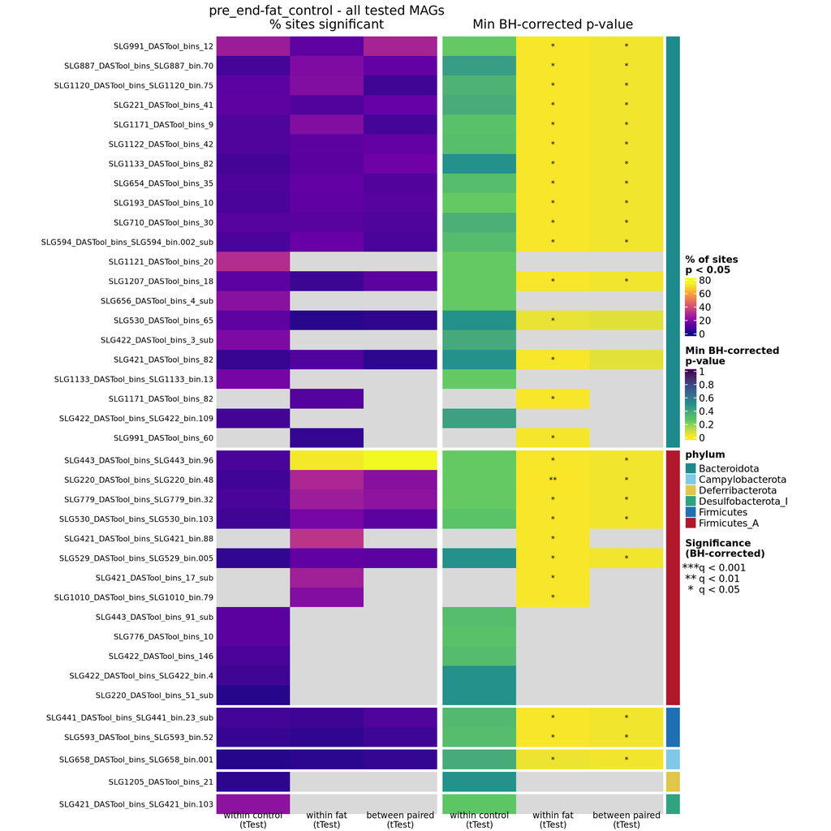

```r
if (have_pval) {
  d <- df_all[
    group_pair == sel_group_pair & test_type %in% tests & period == sel_period
  ]
  if (nrow(d) == 0) {
    cat(
      "No heatmap rows for period =", sel_period,
      "group_pair =", sel_group_pair,
      "with tests:", paste(tests, collapse = ", "), "\n"
    )
  } else {
    # Colour scale: 0 -> the largest % seen in this period.
    pct_col <- make_pct_col(max(d[[value]], na.rm = TRUE))
    mat <- build_matrix(d, value)
    mat_minq <- build_matrix(d, "min_q_value")
    # Every tested MAG is shown; MAGs with no signal simply read as 0%.
    cat(sprintf(
      "%s: %d MAGs shown (%d with >=1 significant site)\n",
      sel_period,
      nrow(mat),
      sum(rowSums(mat > 0, na.rm = TRUE) > 0)
    ))
    ttl <- sprintf("%s-%s - all tested MAGs", sel_period, sel_group_pair)
    two_panel(mat, mat_minq, ttl, pct_col)
    # Same figure again, saved to disk. ComplexHeatmap draws to a device, so there is no
    # ggsave equivalent — we simply redraw inside png()/dev.off(). PNG only (300 dpi), so
    # the figure displays inline on GitHub; swap png() for pdf() if a vector copy is needed.
    png(
      file.path(
        fig_dir,
        sprintf("pvalue_heatmap_%s-%s.png", sel_period, sel_group_pair)
      ),
      width = hm_fig_width,
      height = hm_fig_height,
      units = "in",
      res = 300
    )
    two_panel(mat, mat_minq, ttl, pct_col)
    dev.off()
  }
}
```